# 03_PISA

Sara Bengoechea Rodriguez

11/5/2020

# Limpieza de datos

Cambiamos el nombre de las columnas para que todas ellas estén en minúsculas, se eliminan las filas con valores nulos y las columnas con variables que no necesitaremos y se comprueba que no haya duplicados. El resultado sería el siguiente:

```
## # A tibble: 6 x 8
##   country   overall interest support income health   edu   hdi
##   <chr>       <dbl>    <dbl>   <dbl>  <dbl>  <dbl> <dbl> <dbl>
## 1 Argentina     391      567     506  0.678  0.868 0.786 0.773
## 2 Australia     527      465     487  0.826  0.965 0.978 0.92
## 3 Austria       511      507     515  0.835  0.944 0.824 0.866
## 4 Belgium       510      503     492  0.831  0.935 0.868 0.877
## 5 Brazil        390      592     519  0.637  0.818 0.646 0.695
## 6 Bulgaria      434      523     527  0.663  0.829 0.778 0.753
```

# Summary

Visualizamos un resumen de los estadísticos más relevantes. Podemos observar que ninguna variable sigue una aparente distribución normal, excepto "support".

Data summary

| Name | data_pisa |
| --- | --- |
| Number of rows | 52 |
| Number of columns | 8 |
| _______________________ |  |
| Column type frequency: |  |
| character | 1 |
| numeric | 7 |
| ________________________ |  |
| Group variables | None |

**Variable type: character**

| skim_variable | n_missing | complete_rate | min | max | empty | n_unique | whitespace |
| --- | --- | --- | --- | --- | --- | --- | --- |
| country | 0 | 1 | 5 | 18 | 0 | 52 | 0 |

**Variable type: numeric**

| skim_variable | n_missing | complete_rate | mean | sd | p0 | p25 | p50 | p75 | p100 | hist |
| --- | --- | --- | --- | --- | --- | --- | --- | --- | --- | --- |
| overall | 0 | 1 | 471.15 | 53.99 | 322.00 | 427.00 | 488.00 | 511.25 | 563.00 | ▁▃▃▇▃ |
| interest | 0 | 1 | 527.81 | 50.42 | 448.00 | 498.00 | 522.00 | 565.50 | 644.00 | ▆▇▅▃▂ |
| support | 0 | 1 | 510.88 | 26.37 | 447.00 | 491.75 | 511.50 | 529.00 | 569.00 | ▂▃▇▅▂ |
| income | 0 | 1 | 0.75 | 0.11 | 0.41 | 0.68 | 0.77 | 0.83 | 0.91 | ▁▁▆▅▇ |
| health | 0 | 1 | 0.89 | 0.06 | 0.74 | 0.84 | 0.91 | 0.94 | 0.99 | ▂▃▆▆▇ |
| edu | 0 | 1 | 0.81 | 0.11 | 0.54 | 0.76 | 0.83 | 0.90 | 0.99 | ▂▃▆▇▆ |
| hdi | 0 | 1 | 0.81 | 0.09 | 0.58 | 0.76 | 0.84 | 0.88 | 0.94 | ▁▃▆▆▇ |

# Correlación

Para observar la relación que hay entre las variables realizamos ggplots de la variable overall y las independientes. Para que se pueda estudiar de manera más clara, añadimos logaritmos a la variable dependiente.

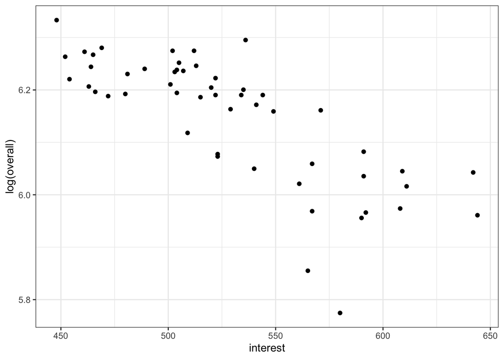

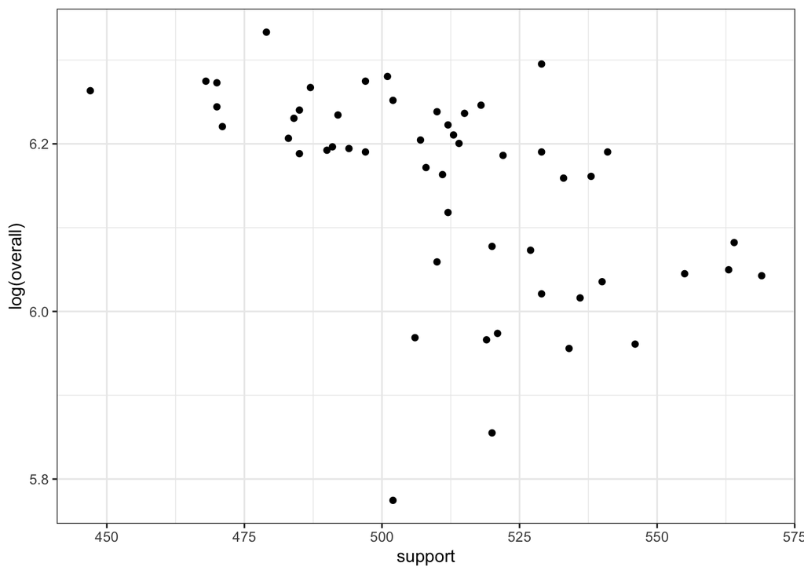

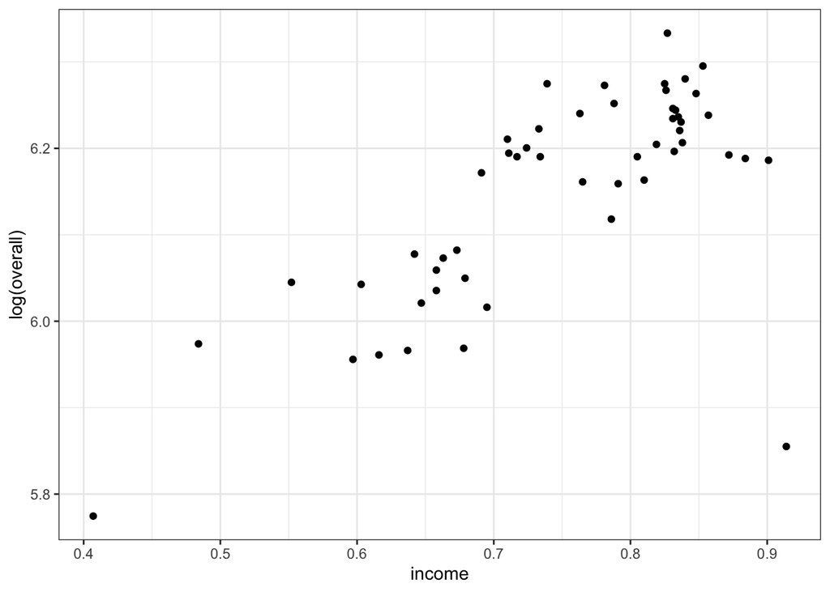

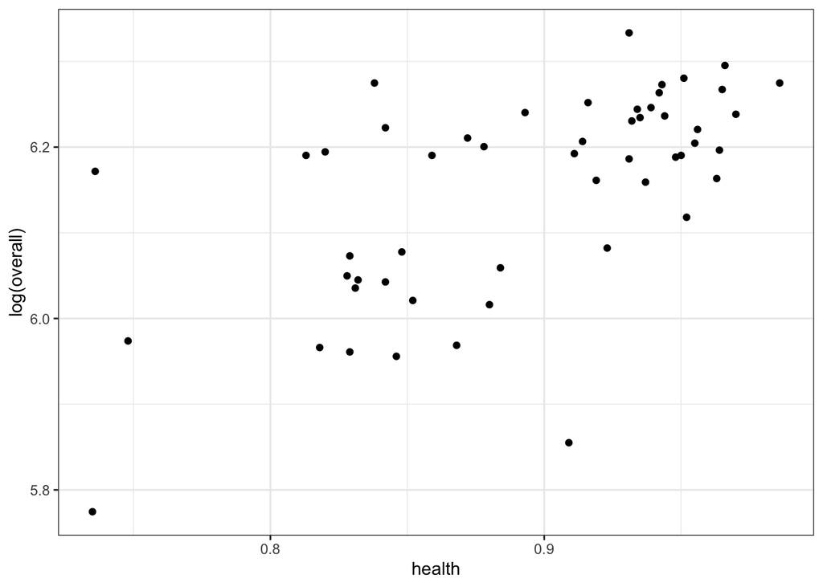

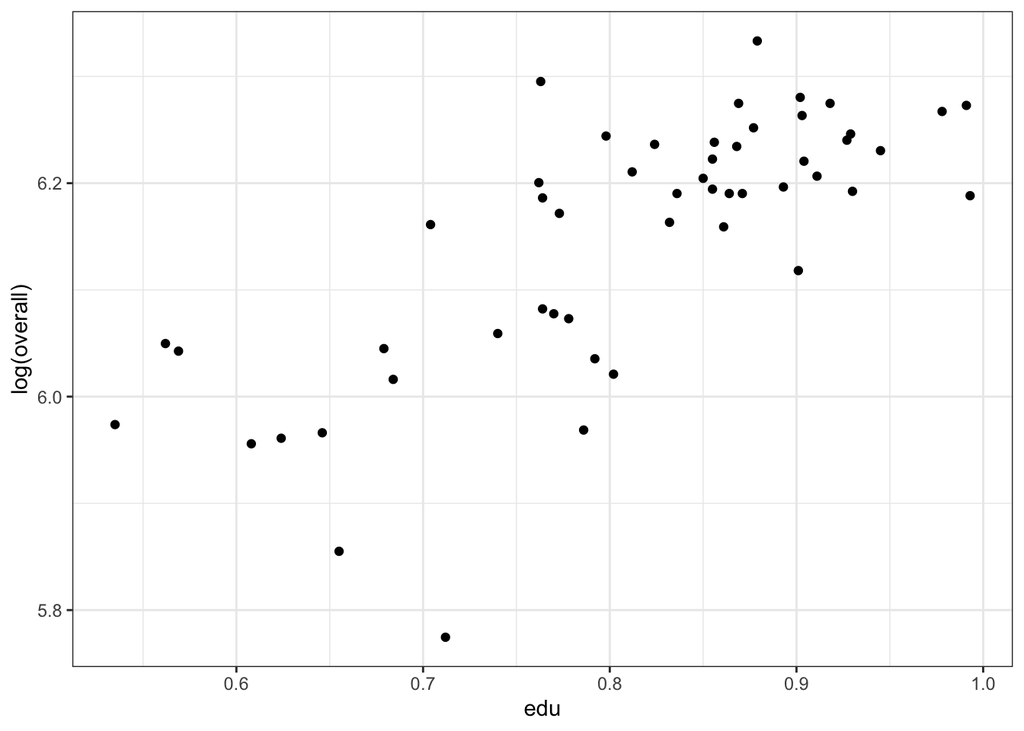

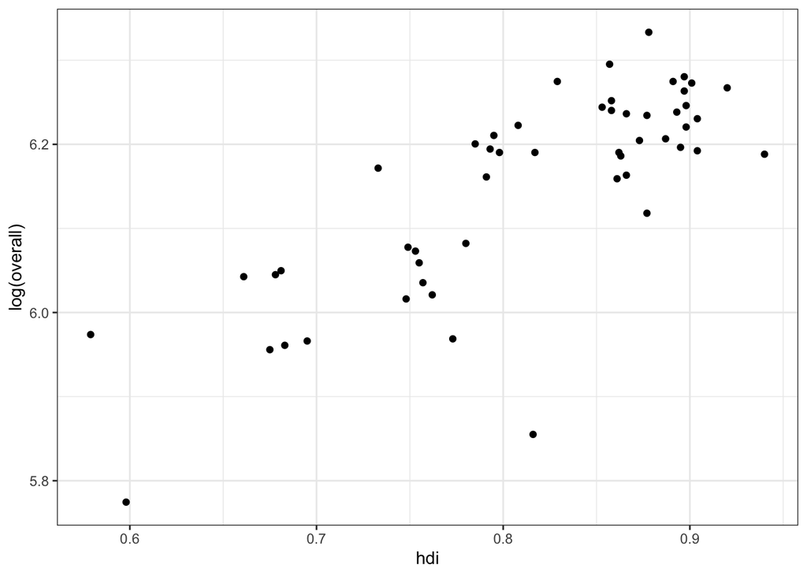

Todas las variables tienen una relación positiva lineal con la variable dependiente excepto interest y support cuya relación es negativa. Además, aparentemente, no existe una clara correlación con la variable support, lo que nos lleva a pensar que support no explique mucho de Overall.

Para asegurarnos de ello realizamos la matriz de correlaciones. De aquí nos interesa fijarnos en la primera línea, donde, como comentado anteriormente, la variable menos correlacionada es support.

```
## Note: Using an external vector in selections is ambiguous.
## ℹ Use `all_of(categorical)` instead of `categorical` to silence this message.
## ℹ See <https://tidyselect.r-lib.org/reference/faq-external-vector.html>.
```

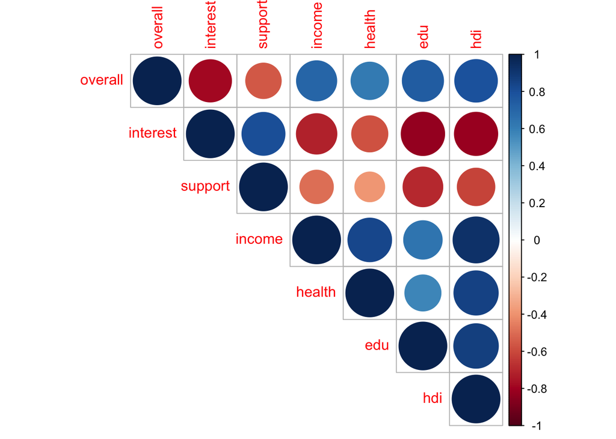

En el siguiente gráfico podemos ver la distribución de cada variable en la diagonal. Por debajo: diagramas de dispersión por pares con línea de ajuste. Por encima: el valor del coef de corr con el nds como estrellas: p-valores(0, 0.001, 0.01, 0.05, 0.1, 1) con símbolos("**", "**", "", ".", " ") respectivamente.

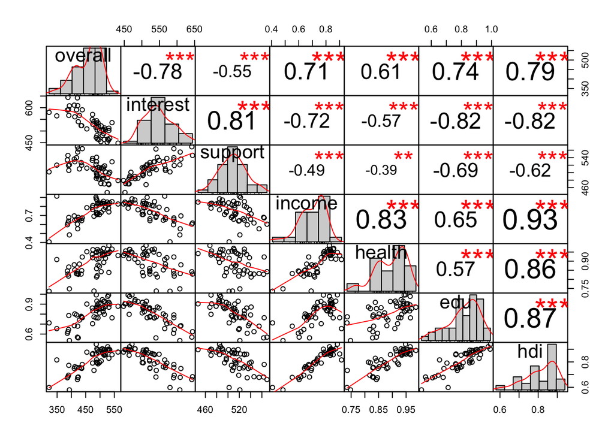

# Generación de splines

A continuacióon utilizamos la función smooth.spline a cada variable, para obtener los splines suavizados de cada uno utilizando el método de cross-validation.

```
## Call:
## smooth.spline(x = data_pisa$interest, y = data_pisa$overall,
##     cv = TRUE)
##
## Smoothing Parameter  spar= 0.9237649  lambda= 0.004107798 (13 iterations)
## Equivalent Degrees of Freedom (Df): 4.726395
## Penalized Criterion (RSS): 44413.01
## PRESS(l.o.o. CV): 1052.927
```

```
## Call:
## smooth.spline(x = data_pisa$support, y = data_pisa$overall, cv = TRUE)
##
## Smoothing Parameter  spar= 1.499951  lambda= 133.0764 (28 iterations)
## Equivalent Degrees of Freedom (Df): 2.000681
## Penalized Criterion (RSS): 65519.24
## PRESS(l.o.o. CV): 2099.773
```

```
## Call:
## smooth.spline(x = data_pisa$income, y = data_pisa$overall, cv = TRUE)
##
## Smoothing Parameter  spar= 0.8203362  lambda= 6.519462e-05 (11 iterations)
## Equivalent Degrees of Freedom (Df): 10.38038
## Penalized Criterion (RSS): 23848.52
## PRESS(l.o.o. CV): 956.007
```

```
## Call:
## smooth.spline(x = data_pisa$health, y = data_pisa$overall, cv = TRUE)
##
## Smoothing Parameter  spar= 1.499957  lambda= 34.62789 (26 iterations)
## Equivalent Degrees of Freedom (Df): 2.003068
## Penalized Criterion (RSS): 85181.93
## PRESS(l.o.o. CV): 1962.029
```

```
## Call:
## smooth.spline(x = data_pisa$edu, y = data_pisa$overall, cv = TRUE)
##
## Smoothing Parameter  spar= 1.029385  lambda= 0.006408888 (14 iterations)
## Equivalent Degrees of Freedom (Df): 4.331208
## Penalized Criterion (RSS): 56937.84
## PRESS(l.o.o. CV): 1307.827
```

```
## Call:
## smooth.spline(x = data_pisa$hdi, y = data_pisa$overall, cv = TRUE)
##
## Smoothing Parameter  spar= 1.499947  lambda= 27.0182 (27 iterations)
## Equivalent Degrees of Freedom (Df): 2.003388
## Penalized Criterion (RSS): 52198.43
## PRESS(l.o.o. CV): 1134.765
```

La siguientegráfico compara el uso de los grados de libertad que he impuesto (10) (línea rosa), y los grados de libertad generados por los splines suavizados a través de cross-validation (línea verde).

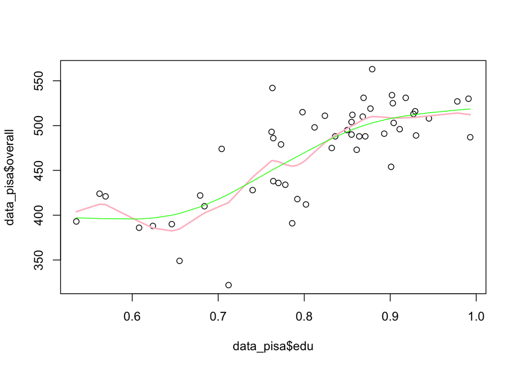

# MODELOS ADITIVOS GENERALIZADOS (GAM)

Lo siguiente es generar un modelo GAM con los grados de libertad obtenidos anteriormente.

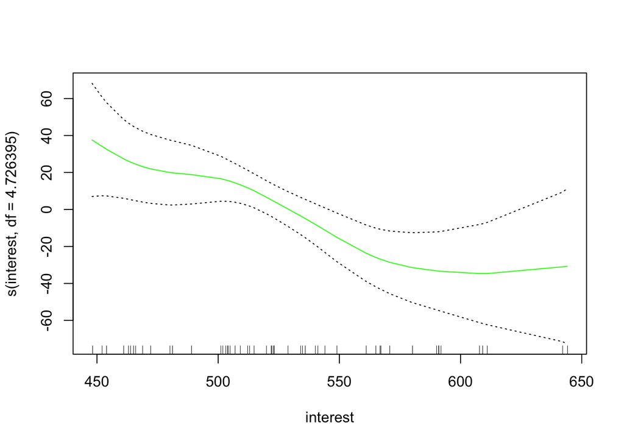

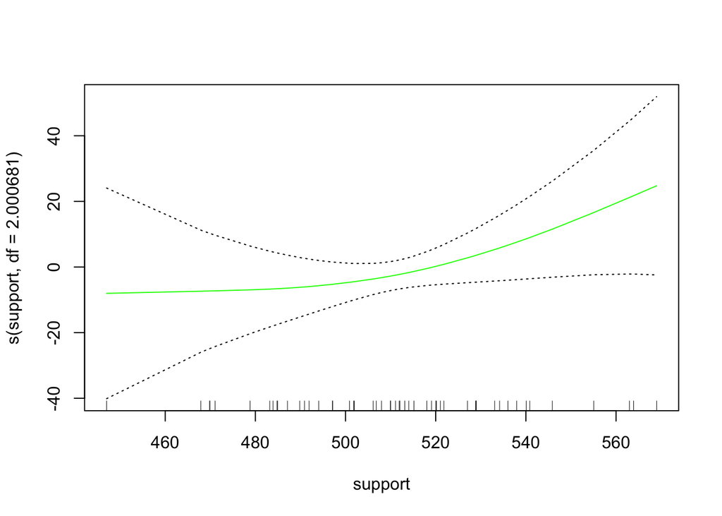

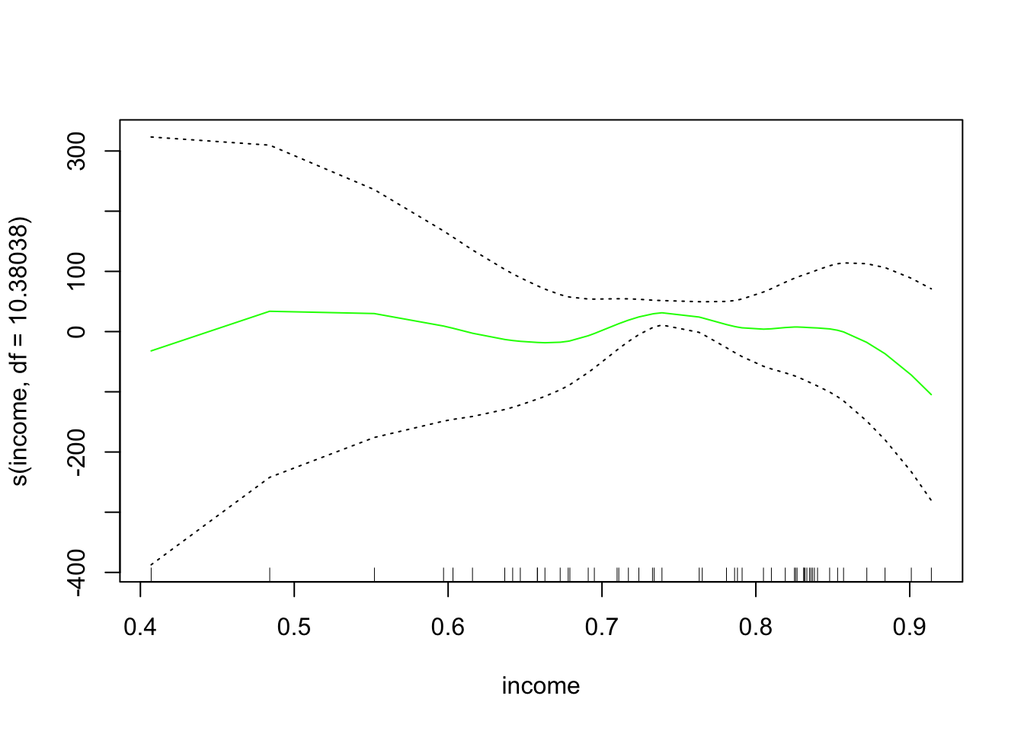

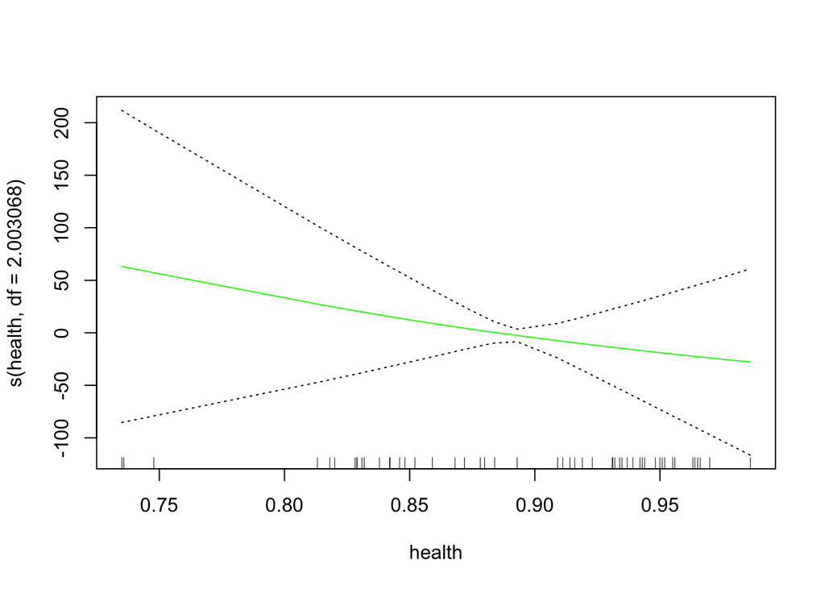

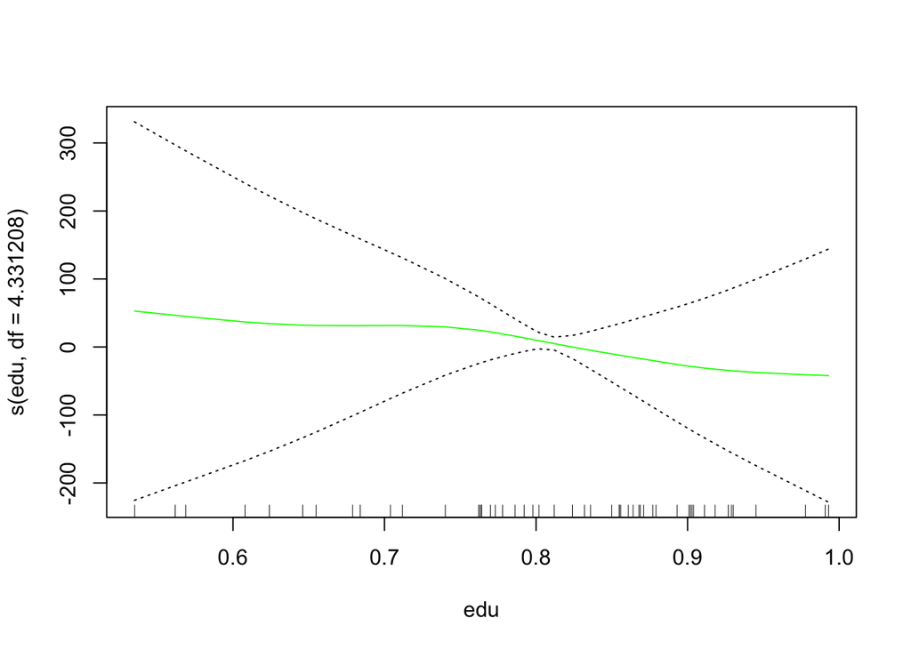

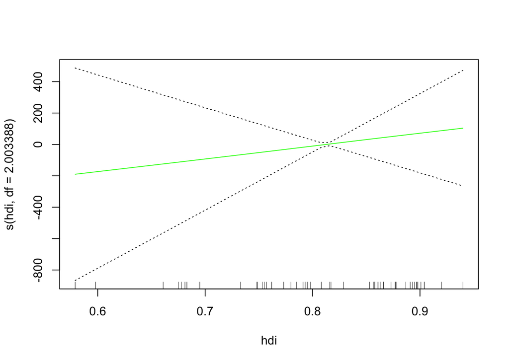

```
##
## Call: gam(formula = overall ~ s(interest, df = 4.726395) + s(support,
##     df = 2.000681) + s(income, df = 10.38038) + s(health, df = 2.003068) +
##     s(edu, df = 4.331208) + s(hdi, df = 2.003388), data = data_pisa)
## Deviance Residuals:
##     Min      1Q  Median      3Q     Max
## -41.886  -7.852  -1.013   6.380  34.485
##
## (Dispersion Parameter for gaussian family taken to be 448.4602)
##
##     Null Deviance: 148644.8 on 51 degrees of freedom
## Residual Deviance: 11460.27 on 25.5547 degrees of freedom
## AIC: 483.0209
##
## Number of Local Scoring Iterations: 7
##
## Anova for Parametric Effects
##                                Df Sum Sq Mean Sq  F value    Pr(>F)
## s(interest, df = 4.726395)  1.000  69467   69467 154.9006 2.387e-12 ***
## s(support, df = 2.000681)   1.000   3020    3020   6.7346   0.01545 *
## s(income, df = 10.38038)    1.000  13097   13097  29.2036 1.226e-05 ***
## s(health, df = 2.003068)    1.000    353     353   0.7862   0.38352
## s(edu, df = 4.331208)       1.000    419     419   0.9334   0.34304
## s(hdi, df = 2.003388)       1.000    144     144   0.3200   0.57653
## Residuals                  25.555  11460     448
## ---
## Signif. codes:  0 '***' 0.001 '**' 0.01 '*' 0.05 '.' 0.1 ' ' 1
##
## Anova for Nonparametric Effects
##                            Npar Df Npar F    Pr(F)
## (Intercept)
## s(interest, df = 4.726395)     3.7 1.6647 0.191751
## s(support, df = 2.000681)      1.0 2.2826 0.143087
## s(income, df = 10.38038)       9.4 4.4591 0.001246 **
## s(health, df = 2.003068)       1.0 1.5229 0.228503
## s(edu, df = 4.331208)          3.3 3.1462 0.038139 *
## s(hdi, df = 2.003388)          1.0 0.1147 0.738485
## ---
## Signif. codes:  0 '***' 0.001 '**' 0.01 '*' 0.05 '.' 0.1 ' ' 1
```

```r
gam1 <- gam(overall ~ s(interest, df=4.726395) + s(support, df=2.000681) + s(income, df=10.38038) + s(health, df=2.003068)+ s(edu, df=4.331208)+ s(hdi, df=2.003388), data = data_pisa )

plot(gam1, se = TRUE, col = 'green')
```

Ya que el objetivo de suavizar splines que encontrar una función que haga que el RSS sea razonablemente pequeño, pero que también sea fluido, observamos los RSS generados con smooth.spline() y generamos un nuevo modelo GAM en el que no están suavizadas aquellas variables que tenían menor RSS.

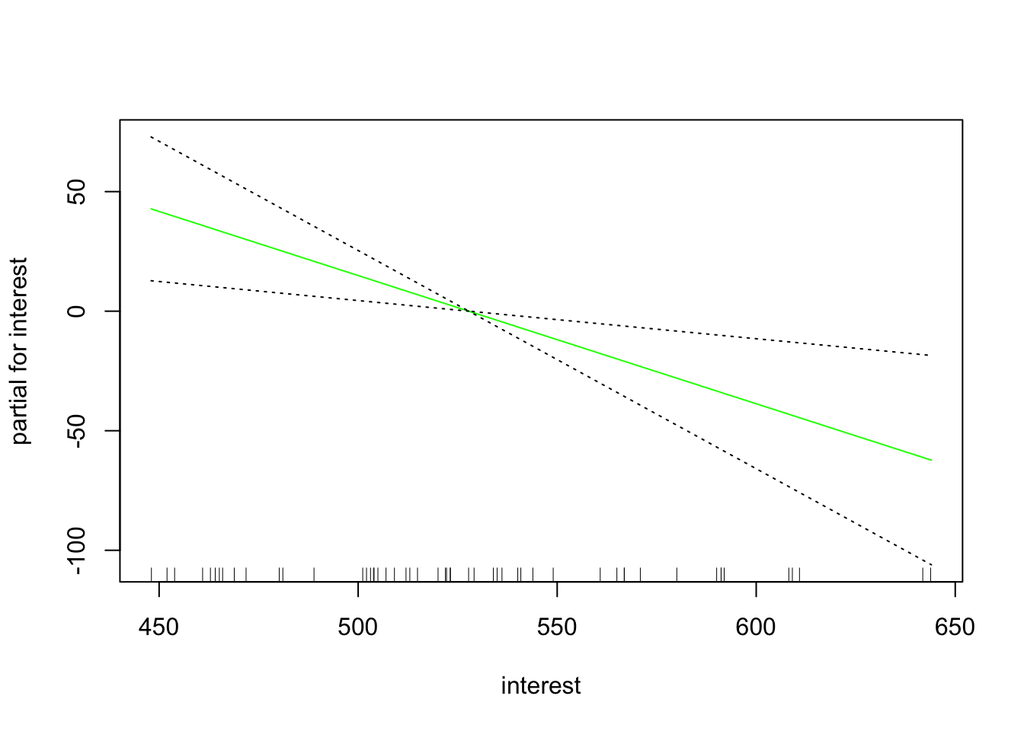

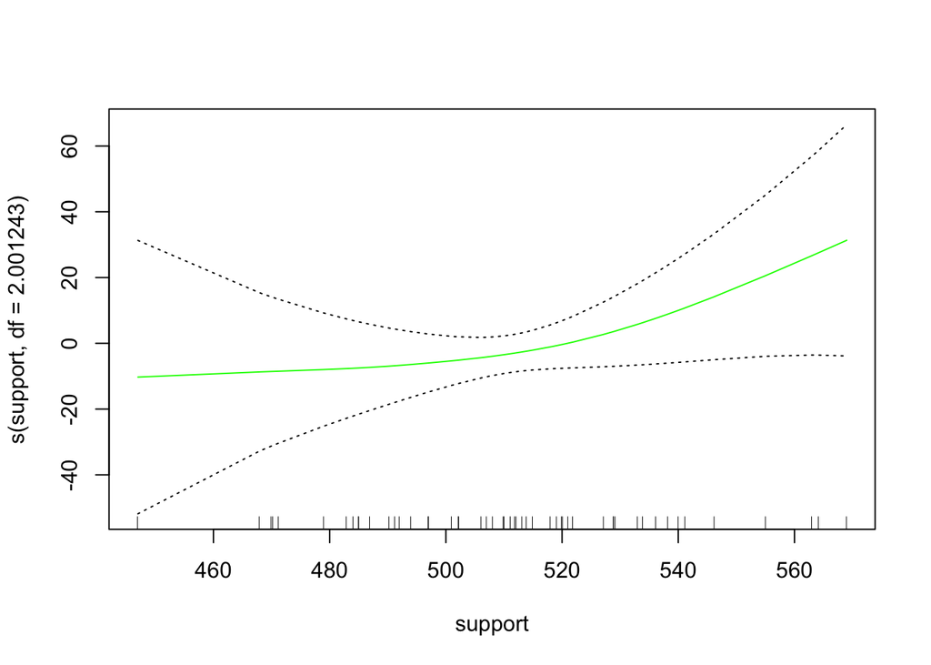

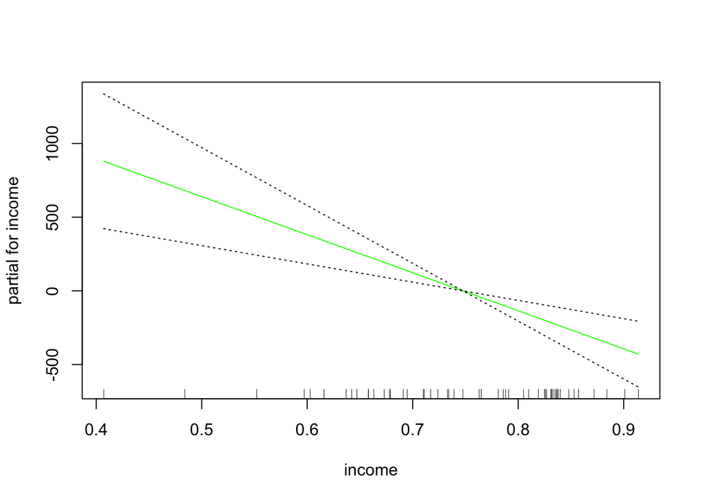

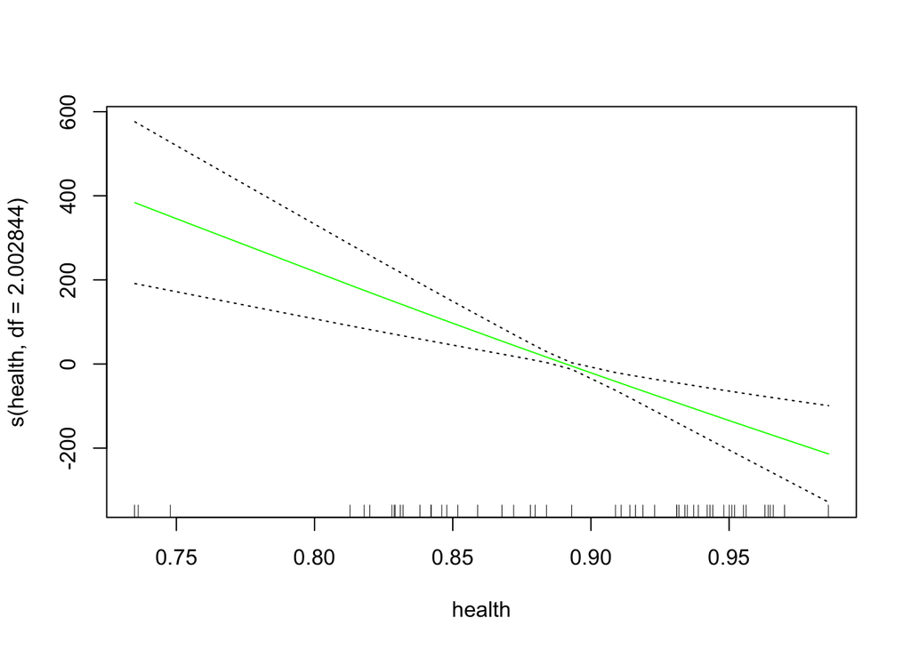

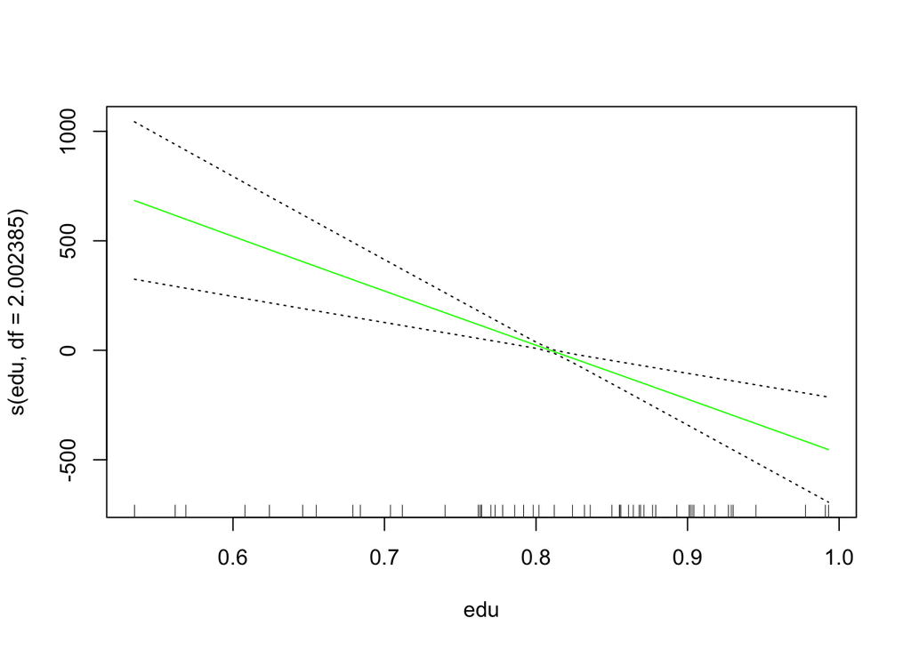

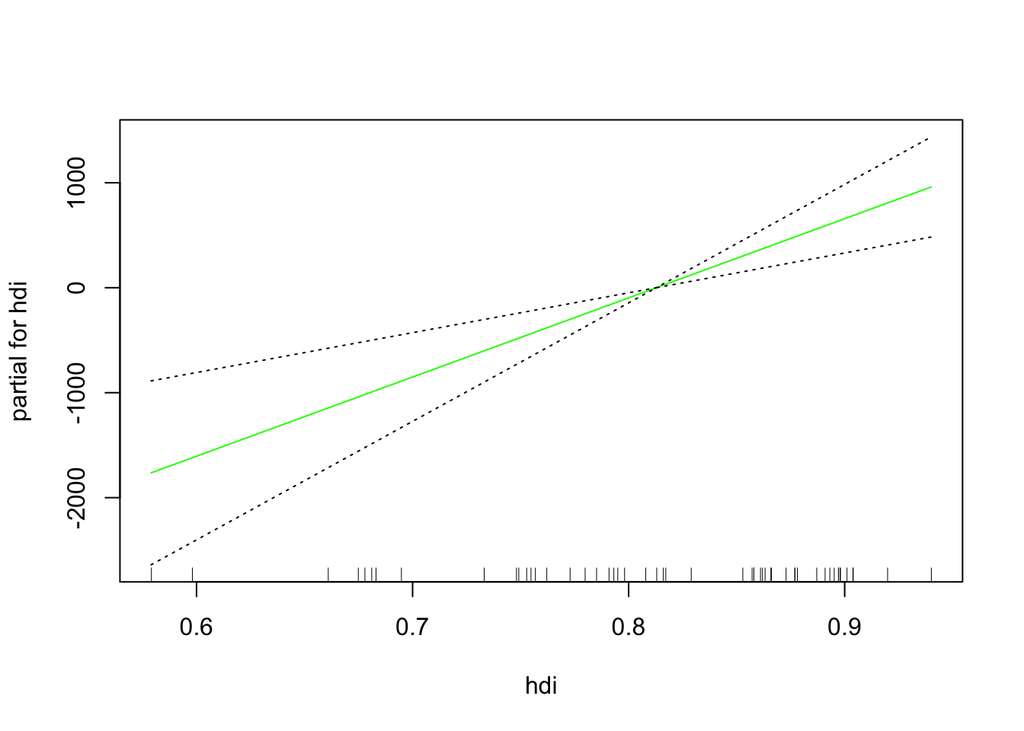

```
##
## Call: gam(formula = overall ~ interest + s(support, df = 2.001243) +
##     income + s(health, df = 2.002844) + s(edu, df = 2.002385) +
##     hdi, data = data_pisa)
## Deviance Residuals:
##     Min      1Q  Median      3Q     Max
## -45.923 -18.110   1.242  14.469  65.936
##
## (Dispersion Parameter for gaussian family taken to be 751.8643)
##
##     Null Deviance: 148644.8 on 51 degrees of freedom
## Residual Deviance: 31573.32 on 41.9934 degrees of freedom
## AIC: 502.8417
##
## Number of Local Scoring Iterations: 2
##
## Anova for Parametric Effects
##                               Df Sum Sq Mean Sq  F value    Pr(>F)
## interest                   1.000  88554   88554 117.7794  9.24e-14 ***
## s(support, df = 2.001243)  1.000   3575    3575   4.7548 0.0348695 *
## income                     1.000   5768    5768   7.6714 0.0083184 **
## s(health, df = 2.002844)   1.000    396     396   0.5262 0.4722141
## s(edu, df = 2.002385)      1.000   3984    3984   5.2987 0.0263688 *
## hdi                        1.000  12192   12192  16.2163 0.0002317 ***
## Residuals                 41.993  31573     752
## ---
## Signif. codes:  0 '***' 0.001 '**' 0.01 '*' 0.05 '.' 0.1 ' ' 1
##
## Anova for Nonparametric Effects
##                           Npar Df  Npar F  Pr(F)
## (Intercept)
## interest
## s(support, df = 2.001243)       1 2.46361 0.1240
## income
## s(health, df = 2.002844)        1 1.81638 0.1850
## s(edu, df = 2.002385)           1 0.39441 0.5339
## hdi
```

```r
gam2 <- gam(overall ~ interest + s(support, df=2.001243) + income + s(health, df=2.002844)+ s(edu, df=2.002385)+ hdi, data = data_pisa )

plot(gam2, se = TRUE, col = 'green')
```

Por último, generamos otro modelo gam sin suavizar ningún splin.

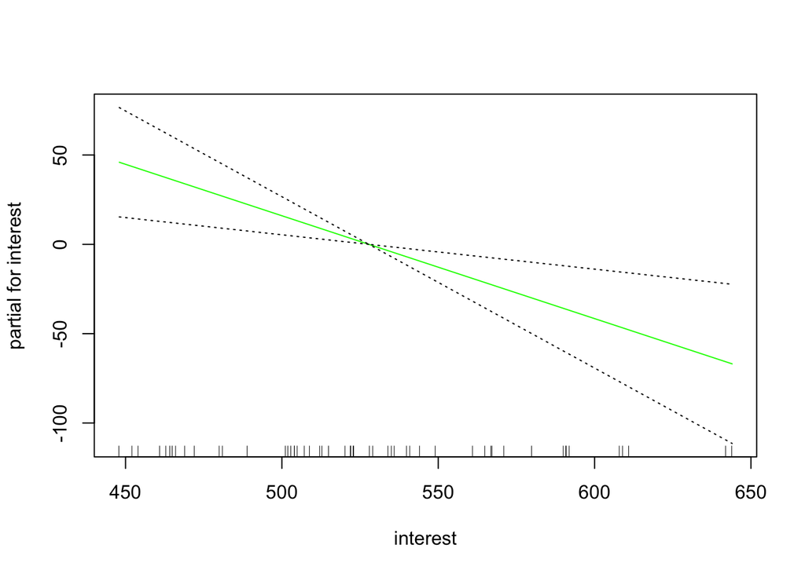

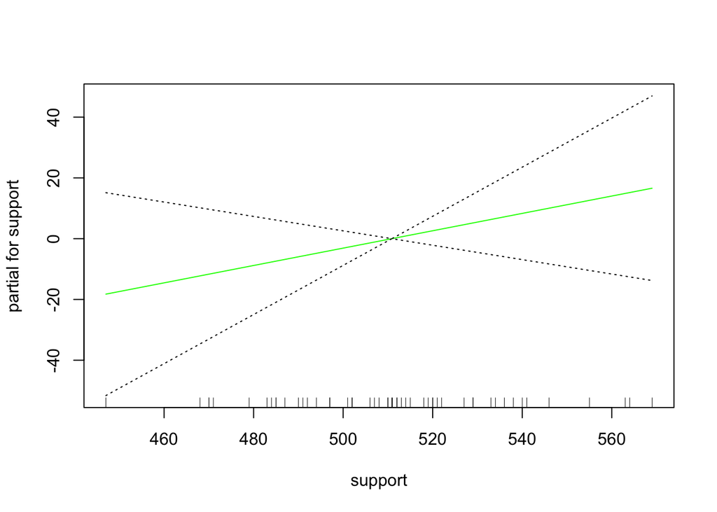

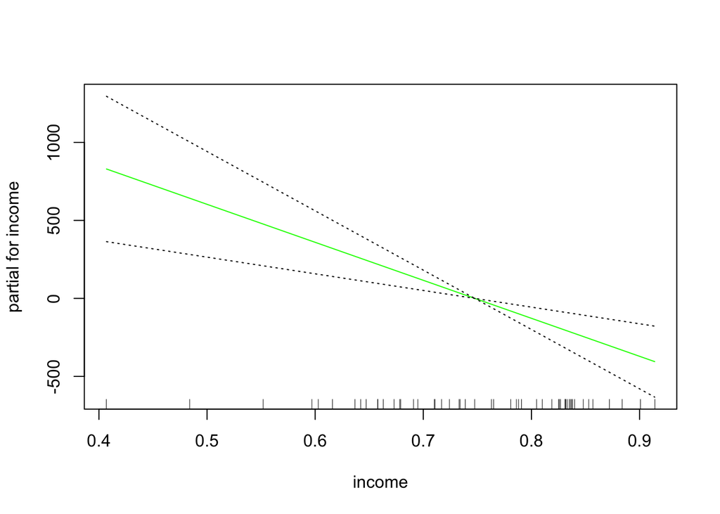

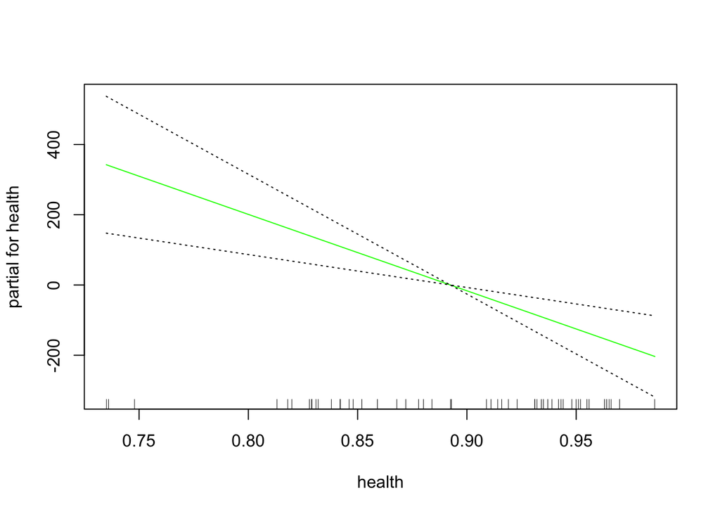

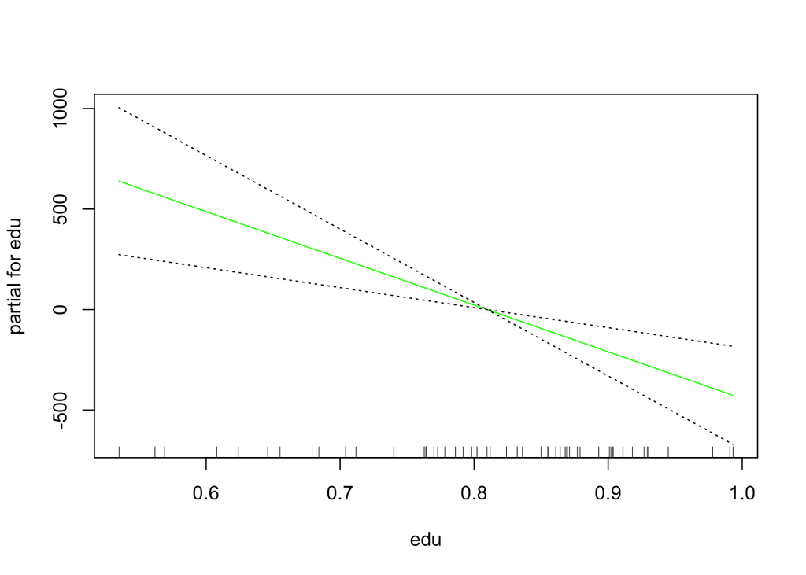

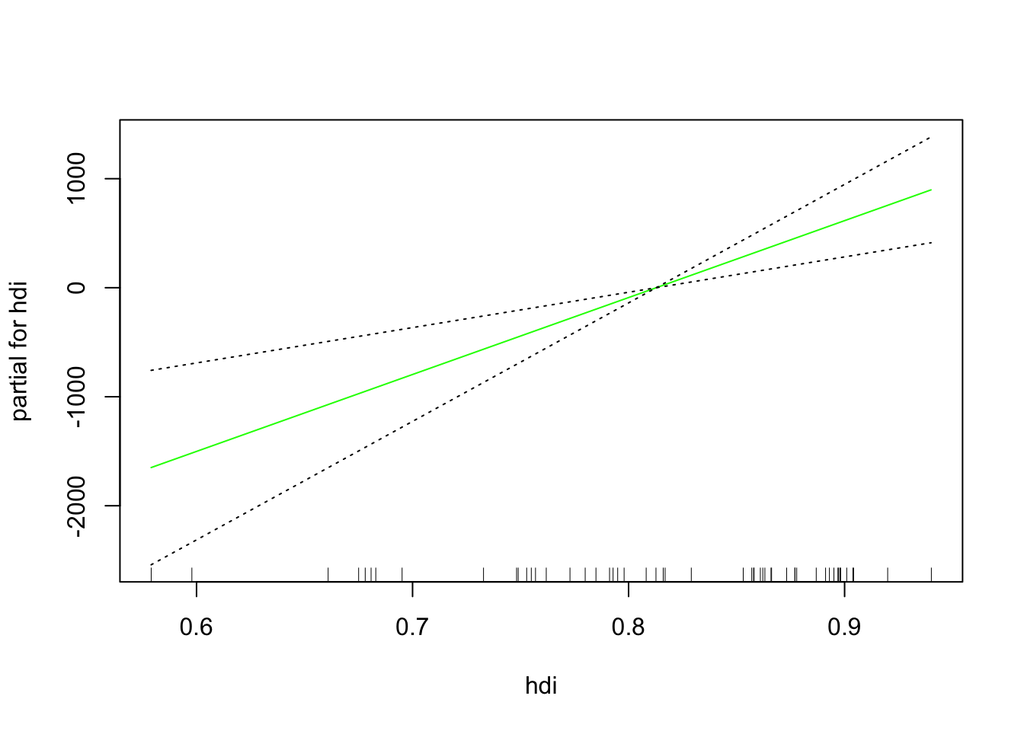

```
##
## Call: gam(formula = overall ~ interest + support + income + health +
##     edu + hdi, data = data_pisa)
## Deviance Residuals:
##     Min      1Q  Median      3Q     Max
## -53.101 -21.326   2.455  17.847  66.605
##
## (Dispersion Parameter for gaussian family taken to be 779.3536)
##
##     Null Deviance: 148644.8 on 51 degrees of freedom
## Residual Deviance: 35070.91 on 45 degrees of freedom
## AIC: 502.2916
##
## Number of Local Scoring Iterations: 2
##
## Anova for Parametric Effects
##           Df Sum Sq Mean Sq  F value    Pr(>F)
## interest   1  91293   91293 117.1387  4.12e-14 ***
## support    1   2856    2856   3.6641 0.0619680 .
## income     1   4963    4963   6.3681 0.0152197 *
## health     1    751     751   0.9642 0.3313809
## edu        1   3040    3040   3.9004 0.0544296 .
## hdi        1  10672   10672  13.6928 0.0005843 ***
## Residuals 45  35071     779
## ---
## Signif. codes:  0 '***' 0.001 '**' 0.01 '*' 0.05 '.' 0.1 ' ' 1
```

```r
gam3 <- gam(overall ~ interest + support + income + health + edu + hdi, data = data_pisa )

plot(gam3, se = TRUE, col = 'green')
```

# ANOVA

Para finalizar, utilizamos ANOVA para evaluar cuál es el mejor modelo.

Atendiendo al RSS, el mejor modelo es gam1, ya que el número de residuos es mucho menor que los otros dos modelos.

```
## Analysis of Deviance Table
##
## Model 1: overall ~ s(interest, df = 4.726395) + s(support, df = 2.000681) +
##     s(income, df = 10.38038) + s(health, df = 2.003068) + s(edu,
##     df = 4.331208) + s(hdi, df = 2.003388)
## Model 2: overall ~ interest + s(support, df = 2.001243) + income + s(health,
##     df = 2.002844) + s(edu, df = 2.002385) + hdi
## Model 3: overall ~ interest + support + income + health + edu + hdi
##   Resid. Df Resid. Dev       Df Deviance  Pr(>Chi)
## 1    25.555      11460
## 2    41.993      31573 -16.4387 -20113.1 0.0001879 ***
## 3    45.000      35071  -3.0066  -3497.6 0.0506103 .
## ---
## Signif. codes:  0 '***' 0.001 '**' 0.01 '*' 0.05 '.' 0.1 ' ' 1
```